# Intro to Tidyverse Workshop

Bin Chen

2022-09-29

Welcome to the “Introduction to Tidyverse” workshop! This is the second training of the two sequence R workshop this fall. In this training, we will (1) review key concepts from the first training (e.g., working directory, data types and structures); (2) use most common commands about the R package `tidyverse`; and (3) walk through a standard data analysis flow by using the `tidyverse` package and knit `.RMD` file to a `HTML` file.

For working directory issues, please follow the instructions to set your Rstudio:

- Click “Tools” in Rstudio, and click “Global Options” from the option lists.
- Click “R Markdown” from the pop-up window “Options”.
- Look for “Evaluate chunks in directory”
- Change the default option “Document” to “Project”

Then do the followings: - Create a new R project, and three folders `data`, `R`, and `output`. - Place the input data file `gamesale.csv` in the `data` subfolder. - Place the RMD file `tidyverse_workshop_incomplete.csv` in the `R` subfolder.

The dataset `gamesale.csv` includes the world-wide sales data of video games. The description of the variables included in the data file is as follows:

- `Rank` - Ranking of overall sales
- `Name` - Video game names
- `Platform` - Platform of the games release (i.e. PC,PS4, etc.)
- `Year` - Year of the game’s release
- `dual_sim` - Has dual sim support or not
- `Genre` - Genre of the game
- `Publisher` - Publisher of the game
- `NA_Sales` - Sales in North America(in millions)
- `EU_Sales` - Sales in Europe(in millions)
- `JP_Sales` - Sales in Japan(in millions)
- `Other_Sales` - Sales in other areas of the world(in millions)
- `Global_Sales` - Total worldwide sales(in millions)

For more information, you could refer to this webpage [https://www.kaggle.com/gregorut/videogamesales], from which the dataset was downloaded.

Credit to Dr. Seung Choi for introducing this dataset.

# 1 What is `tidyverse`?

The tidyverse is a collection of R packages designed for data science.

A list of packages that we used most but not all

- `readr`
- `dplyr`
- `tidyr`
- `stringr`
- `ggplot2`

For more information, visit [https://www.tidyverse.org/packages/]

# 2 R Data Analysis Workflow

## 2.1 Import Data

- base R or `readr`: for flat files (e.g., `.csv`)
- `jsonlite` package for JSON data
- `haven` package for SPSS, STATA, and SAS data

## 2.2 Data Wrangling

- `tidyr`
- `dplyr`
- `lubridate` for dates and date-times data

## 2.3 Data Visualization

Normally, you will want to do some statistical modeling or other analysis after data cleaning and wrangling. But we will not discuss it here.

- `ggplot2`

# 3 Preparation

## 3.1 Install the package

Run `install.package("tidyverse")` in console. Because you only need to install it for once. Run `library(tidyverse)` to load the package

```r
library(tidyverse)
```

## 3.2 Forward pipe operator `%>%`

The infix operator `%>%` is not part of base R, but is in fact defined by the package `magrittr` and is heavily used by `dplyr`.

```r
x <- c("high", "low", "high")
```

```r
x1 <- as.factor(x)
```

```r
x2 <- x %>%
  as.factor()
```

```r
x1 == x2
```

```
## [1] TRUE TRUE TRUE
```

# 4 Commands

You may need to use hundreds of commands in a single task or when dealing with different types of data. Here we will only talk about the mostly used ones in standard scenarios.

## 4.1 Import data `read_csv`

```r
df <- read_csv("data/gamesale.csv", na = "N/A")
```

base R command: `read.csv`

```r
df0 <- read.csv("data/gamesale.csv")
```

You may not see any differences between these two but the differences exist. One point is `read_csv` is significantly faster for large .csv files.

There are many options to specify when import data into R (e.g., missing value)

## 4.2 Check Missing Value

Check NA in the whole data frame

```r
sum(is.na(df))
```

```
## [1] 329
```

Check NA by column

```r
sum(is.na(df$Year))
```

```
## [1] 271
```

## 4.3 Convert data type

What is the data type of the column `Year`

```r
class(df$Year)
```

```
## [1] "numeric"
```

We want to convert it to a `integer`

```r
df$Year <- as.integer(df$Year)
```

```r
class(df$Year)
```

```
## [1] "integer"
```

Note: Although we did not do it here - it is always a good habit to create a new column whenever you want to manipulate original data.

## 4.4 Create a new column `mutate`

Lets convert `Platform`, `Genre`, and `Publisher` to `factor` data and create three new columns named `Platform_f`.

```r
df1 <- df %>%
  mutate("Platform_f" = as.factor(Platform),
         "Genre_f" = as.factor(Genre),
         "Publisher_f" = as.factor(Publisher))
```

Lets check

```r
class(df1$Genre_f)
```

```
## [1] "factor"
```

Note. You can use `across()` and `is.charater` to do this more efficiently.

```r
df<- df %>%
  mutate(across(where(is.character), as.factor))
```

## 4.5 Select columns `select()`

Suppose we are only interested in three columns: `Rank`, `Name`, and `Global_sales`

```r
df2 <- df %>%
  select(Rank, Name, Global_Sales)
```

Lets check

```r
colnames(df2)
```

```
## [1] "Rank"         "Name"         "Global_Sales"
```

## 4.6 Subset rows with `subset()`

To subset certain rows, you need specify rules.

Suppose we want to subset top 50 most popular games.

```r
df3 <- df %>%
  subset(Rank <= 50)
```

What if we have multiple conditions? (use `&` and “|”)

```r
df4 <- df %>%
  subset(Rank <= 100 & Platform == "PC")
```

```r
levels(df$Platform)
```

```
##  [1] "2600" "3DO"  "3DS"  "DC"   "DS"   "GB"   "GBA"  "GC"   "GEN"  "GG"
## [11] "N64"  "NES"  "NG"   "PC"   "PCFX" "PS"   "PS2"  "PS3"  "PS4"  "PSP"
## [21] "PSV"  "SAT"  "SCD"  "SNES" "TG16" "Wii"  "WiiU" "WS"   "X360" "XB"
## [31] "XOne"
```

What if we want subset `Platform` is “PC”, “PS3”, “Wii”, “X360”?

Use `%in%` to identify if an element (e.g., a number) belongs to a vector or dataframe

```r
df5 <- df %>%
  subset(Platform %in% c("PC", "PS3", "Wii", "X360"))
```

### 4.6.1 Subset rows with `filter`

Note. `subset()` and `filter()` do same things but `filter()` is faster when data size is large. For more discussions visit [https://stackoverflow.com/questions/39882463/difference-between-subset-and-filter-from-dplyr]

## 4.7 `group_by`

Use `group_by` and `count ()`to list number of games for each `Genre`

```r
df %>%
  group_by(Genre) %>%
  count()
```

```
## # A tibble: 12 x 2
## # Groups:   Genre [12]
##    Genre            n
##    <fct>        <int>
##  1 Action        3316
##  2 Adventure     1286
##  3 Fighting       848
##  4 Misc          1739
##  5 Platform       886
##  6 Puzzle         582
##  7 Racing        1249
##  8 Role-Playing  1488
##  9 Shooter       1310
## 10 Simulation     867
## 11 Sports        2346
## 12 Strategy       681
```

Suppose we want to Compare `Global_sales` by `Genre`

```r
df %>%
  group_by(Genre) %>%
  summarise (sale = mean(Global_Sales))
```

```
## # A tibble: 12 x 2
##    Genre         sale
##    <fct>        <dbl>
##  1 Action       0.528
##  2 Adventure    0.186
##  3 Fighting     0.529
##  4 Misc         0.466
##  5 Platform     0.938
##  6 Puzzle       0.421
##  7 Racing       0.586
##  8 Role-Playing 0.623
##  9 Shooter      0.792
## 10 Simulation   0.452
## 11 Sports       0.567
## 12 Strategy     0.257
```

Lets reorder the table above by `sale` from high to low

```r
df %>%
  group_by(Genre) %>%
  summarise (sale = mean(Global_Sales)) %>%
  arrange(-sale) # notice the nagative sign here
```

```
## # A tibble: 12 x 2
##    Genre         sale
##    <fct>        <dbl>
##  1 Platform     0.938
##  2 Shooter      0.792
##  3 Role-Playing 0.623
##  4 Racing       0.586
##  5 Sports       0.567
##  6 Fighting     0.529
##  7 Action       0.528
##  8 Misc         0.466
##  9 Simulation   0.452
## 10 Puzzle       0.421
## 11 Strategy     0.257
## 12 Adventure    0.186
```

## 4.8 Visualization `ggplot2`

Suppose we want to plot the global sales by game genres

`ggplot()` `aes()` `geom_bar`: `stat=`

Note. To add more layers to a plot, you use `+` rather than `%>%`

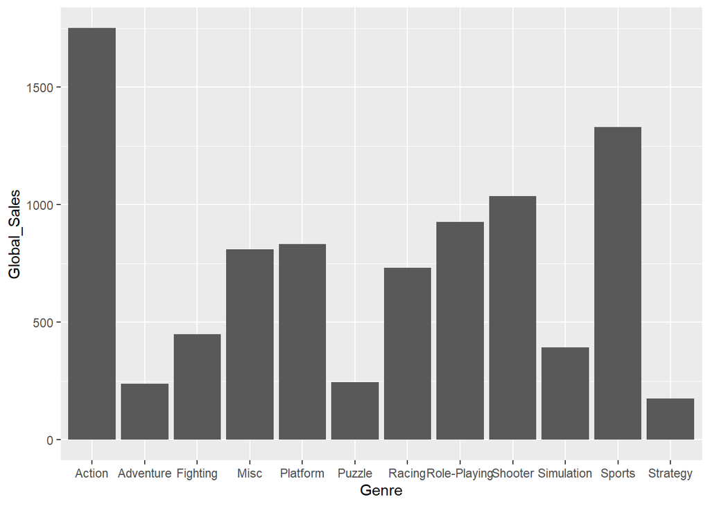

```r
df %>%
  ggplot(aes(x = Genre, y = Global_Sales)) +
  geom_bar(stat='identity')
```

Lets make this plot more informational and prettier

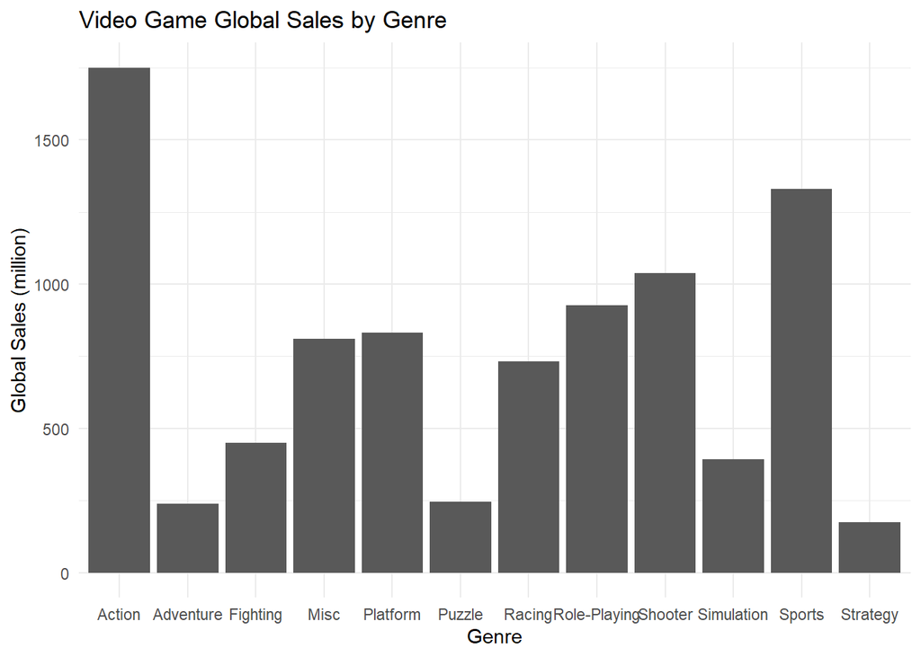

```r
df %>%
  ggplot(aes(x = Genre, y = Global_Sales)) +
  geom_bar(stat='identity') +
  ggtitle("Video Game Global Sales by Genre") +
  ylab ("Global Sales (million)") +
  theme_minimal()
```

# 5 Gamesale data showcase

## 5.1 Load packages

Besides of `tidyverse`, we will use two more packages here

`skimr`: provides a strong set of summary statistics. `kableExtra`: generates tables (upgrade base R `kable`)

You should see the warning upon opening this RMD file of installing packages. If you didn’t do it, use `install.package()` to install packages.

```r
library(skimr)
library(kableExtra)
```

## 5.2 Generate a table

```r
df %>%
  subset(Platform %in% c("PS3", "X360", "Wii", "PC")) %>%
  group_by(Platform) %>%
  summarise(mean_sale_Global = mean(Global_Sales),
            sd_sale_Global = sd(Global_Sales),
            max_sale_Global = max(Global_Sales),
            min_sale_Global = min(Global_Sales)) %>%
  arrange(-mean_sale_Global) %>%
  kable(caption = "Table of Sales of Video Games by Platforms") %>%
  kable_classic(full_width = FALSE, html_font = "Arial")
```

Table of Sales of Video Games by Platforms

| Platform | mean_sale_Global | sd_sale_Global | max_sale_Global | min_sale_Global |
| --- | --- | --- | --- | --- |
| X360 | 0.7746719 | 1.6189057 | 21.82 | 0.01 |
| PS3 | 0.7207223 | 1.4128497 | 21.40 | 0.01 |
| Wii | 0.6994038 | 3.1380555 | 82.74 | 0.01 |
| PC | 0.2696042 | 0.6814934 | 8.11 | 0.01 |

## 5.3 Generate a Plot

```r
unique(df$Genre)
```

```
##  [1] Sports       Platform     Racing       Role-Playing Puzzle
##  [6] Misc         Shooter      Simulation   Action       Fighting
## [11] Adventure    Strategy
## 12 Levels: Action Adventure Fighting Misc Platform Puzzle ... Strategy
```

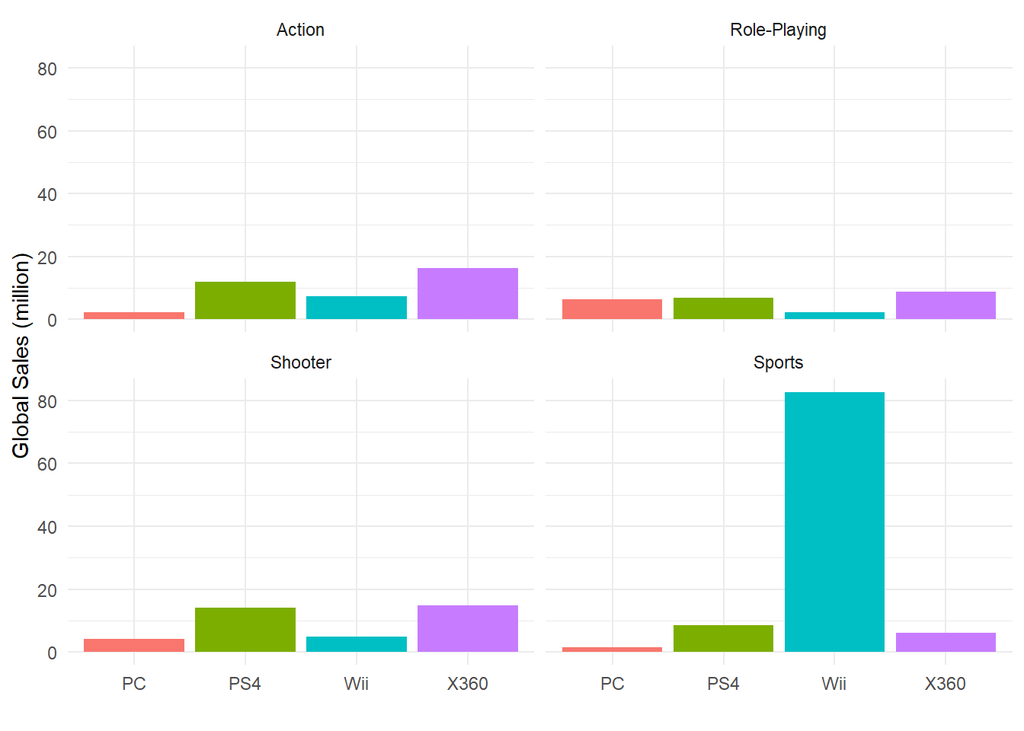

```r
df %>%
  filter(Platform %in% c("PS4", "X360", "Wii", "PC")) %>%
  filter(Genre %in% c("Sports", "Role-Playing", "Shooter", "Action")) %>%
  ggplot(aes(fill=Platform, y=Global_Sales, x=Platform)) +
  geom_bar(position="dodge", stat="identity") +
  theme_minimal() +
  facet_wrap(~Genre) +
  theme(legend.position="none") +
  xlab("") +
  ylab("Global Sales (million)")
```